# Profiling 1

mhv

12/18/2022

```r
library("microbenchmark")
library("ggplot2")
library("magrittr")
```

# Conclusion

- Version 1:
  - Outer function `version1()` takes `df` as input.
  - Inner functions take no input.
    - Modify single elements in `df` in env of outer function based on other single elements of `df` .
    - Each inner function is called in turn inside `version1()`.
- Version 2: quasi-S3 OOP
  - Function `version2()` takes `df` as input.
  - Function `version2()` calls external functions which take `df` from env of `version2()`
  - External functions modify `df` in their own env and output modified `df`.
  - Each external function is called in turn inside `version2()` such that one modifies the output of the previous one.
- Version 3:
  - Same as version 2, except that the functions that modify `df` now are defined inside the outer function `version3()`.
- Version 4:
  - Like version 2, except that external functions are chained inside `version4()` in a pipe with `%>%`.
- Version 5:
  - Functions output single values.
  - Change all modified elements in `df` in one step at the end.

There is no significant difference in performance between the different approaches. In particular, there is no significant difference in performance between the OOP (vserion 2) and FP (version 1+3+4) approaches.

Version 5 seems to show, that it’s fine to store all variables in a large data frame. However, this turns not to be true, as seen in `Profiling 2.Rm` and `Profiling 3.Rmd`.

Question: Can we trust, that there is no difference between the approaches in version 1 - 4? Test this…

Note: There is a big different between the first and second time we run the benchmark. What are the implications of this? Which situation applies most to real world usage?

Looking at median to avoid leverage of outliers.

See also /Users/mhvpbp13/Documents/Notes/Investering/rsystrade/Notes/rsystrade/Development/Coding paradigms - rsystrade.md

# Instructions:

Run everything at once.

# Performance test 1

```r
nrows <- 252 * 25 ## 6300 (25 years of trade data for single table)
#nrows <- 1000000
ncols <- 20
```

## Version 1

- Outer function takes df as input
  - Inner functions take no input.
    - Modify single elements in df based on other single elements of df in env of outer function.

```r
df <- data.frame(matrix(rep(0, nrows * ncols ), ncol = ncols))

version1 <- function(df) {
  v1f1 <- function() {
    df[1, 1] <<- "a"
  }
  v1f2 <- function() {
    df[1, 2] <<- paste0(df[1, 1], "b")
  }
  v1f3 <- function() {
    df[1, 3] <<- paste0(df[1, 2], "c")
  }
  v1f4 <- function() {
    df[1, 4] <<- paste0(df[1, 3], "d")
  }

  v1f1()
  v1f2()
  v1f3()
  v1f4()

  df
}

version1_out <- version1(df)
version1_out[1, 1:4]
```

```
##   X1 X2  X3   X4
## 1  a ab abc abcd
```

```r
rm(df)
```

## Version 2: Quasi-S3 OOP

```r
df <- data.frame(matrix(rep(0, nrows * ncols ), ncol = ncols))

v2f1 <- function(df) {
  df[1, 1] <- "a"
  df
}
v2f2 <- function(df) {
  df[1, 2] <- paste0(df[1, 1], "b")
  df
}
v2f3 <- function(df) {
  df[1, 3] <- paste0(df[1, 2], "c")
  df
}
v2f4 <- function(df) {
  df[1, 4] <- paste0(df[1, 3], "d")
  df
}

version2 <- function(df) {
  df <- v2f1(df)
  df <- v2f2(df)
  df <- v2f3(df)
  df <- v2f4(df)

  df
}

version2_out <- version2(df)
version2_out[1, 1:4]
```

```
##   X1 X2  X3   X4
## 1  a ab abc abcd
```

```r
rm(df)
```

## Version 3

```r
df <- data.frame(matrix(rep(0, nrows * ncols ), ncol = ncols))

version3 <- function(df) {
  v3f1 <- function(df) {
    df[1, 1] <- "a"
    df
  }
  v3f2 <- function(df) {
    df[1, 2] <- paste0(df[1, 1], "b")
    df
  }
  v3f3 <- function(df) {
    df[1, 3] <- paste0(df[1, 2], "c")
    df
  }
  v3f4 <- function(df) {
    df[1, 4] <- paste0(df[1, 3], "d")
    df
  }

  df <- v3f1(df)
  df <- v3f2(df)
  df <- v3f3(df)
  df <- v3f4(df)

  df
}

version3_out <- version3(df)
version3_out[1, 1:4]
```

```
##   X1 X2  X3   X4
## 1  a ab abc abcd
```

```r
rm(df)
```

## Version 4

```r
df <- data.frame(matrix(rep(0, nrows * ncols ), ncol = ncols))

v4f1 <- function(df) {
  df[1, 1] <- "a"
  df
}

v4f2 <- function(df) {
  df[1, 2] <- paste0(df[1, 1], "b")
  df
}

v4f3 <- function(df) {
  df[1, 3] <- paste0(df[1, 2], "c")
  df
}

v4f4 <- function(df) {
  df[1, 4] <- paste0(df[1, 3], "d")
  df
}

version4 <- function(df) {
  df %>%
    v4f1 %>%
    v4f2 %>%
    v4f3 %>%
    v4f4
}

version4_out <- version4(df)
version4_out[1, 1:4]
```

```
##   X1 X2  X3   X4
## 1  a ab abc abcd
```

```r
rm(df)
```

## Version 5

Functions output single values.  
Change all modified elements in df in one step at the end.

```r
df <- data.frame(matrix(rep(0, nrows * ncols ), ncol = ncols))

version5 <- function(df) {
  v5f1 <- function() {
    "a"
  }
  v5f2 <- function(prev) {
    paste0(prev, "b")
  }
  v5f3 <- function(prev) {
    paste0(prev, "c")
  }
  v5f4 <- function(prev) {
    paste0(prev, "d")
  }

  out1 <- v5f1()
  out2 <- v5f2(out1)
  out3 <- v5f3(out2)
  out4 <- v5f4(out3)

  df[1, 1:4] <- c(out1, out2, out3, out4)

  df
}

version5_out <- version5(df)
version5_out[1, 1:4]
```

```
##   X1 X2  X3   X4
## 1  a ab abc abcd
```

```r
rm(df)
```

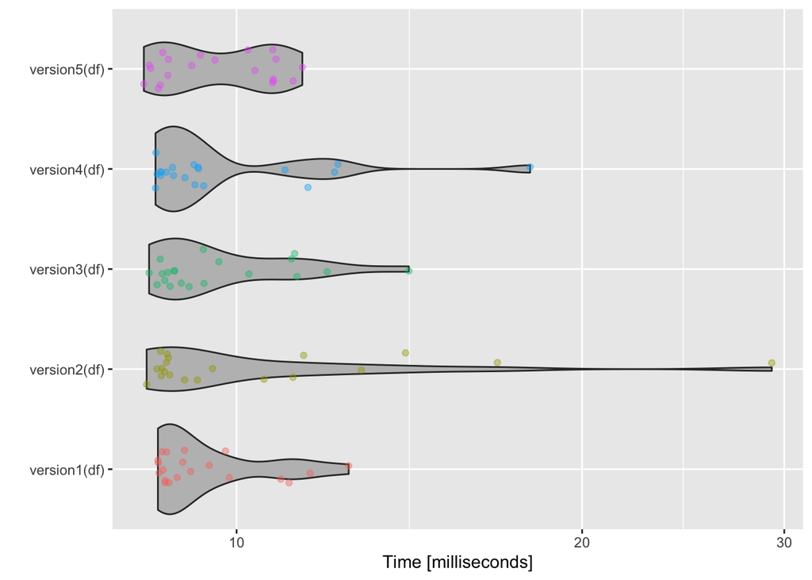

```r
df <- data.frame(matrix(rep(0, nrows * ncols ), ncol = ncols))

mb_out <- microbenchmark(
  version1(df),
  version2(df),
  version3(df),
  version4(df),
  version5(df),
  times = 20L
)

mb_plot <- autoplot(mb_out) +
  geom_jitter(position = position_jitter(0.2, 0),
              aes(color = expr), alpha = 0.4) +
  aes(fill = I("gray")) +
  theme(legend.position = "none")
mb_plot
```

```r
#labs(title = "Kernel smoother", subtitle = "")

rm(df)
```

```r
summary(mb_out)
```

```
##           expr      min       lq      mean   median        uq      max neval
## 1 version1(df) 8.539652 8.644655  9.442620 8.926884  9.816831 12.52135    20
## 2 version2(df) 8.349028 8.632092 11.008596 8.877122 11.318421 29.25863    20
## 3 version3(df) 8.389979 8.685319  9.717312 9.020125 10.705102 14.12814    20
## 4 version4(df) 8.498545 8.590281  9.893141 9.097845 10.189283 18.01889    20
## 5 version5(df) 8.302226 8.603815  9.669665 9.437942 10.759013 11.40950    20
```

Run benchmark test again

```r
df <- data.frame(matrix(rep(0, nrows * ncols ), ncol = ncols))

mb_out <- microbenchmark(
  version1(df),
  version2(df),
  version3(df),
  version4(df),
  version5(df),
  times = 20L
)
summary(mb_out)
```

```
##           expr      min       lq     mean   median       uq      max neval
## 1 version1(df) 8.641549 9.509410 11.26481 10.56883 12.65165 18.76290    20
## 2 version2(df) 8.338568 9.332756 12.68451 12.14660 14.79207 20.82553    20
## 3 version3(df) 8.352355 9.190040 10.29903 10.19092 11.09829 13.65269    20
## 4 version4(df) 8.346661 9.408933 11.85863 11.32859 13.26244 19.81741    20
## 5 version5(df) 8.416434 9.300103 11.46122 10.72094 13.04704 16.41606    20
```

```r
rm(df)
```